# US Police Shooting: EDA

attention: in progress ...

## Origin DataSet

[Kaggle DataSet: US Police Shooting](https://www.kaggle.com/ahsen1330/us-police-shootings)

[highcharts GEOJSON Maps](http://code.highcharts.com/mapdata/)

- [Direck link](http://code.highcharts.com/mapdata/countries/us/us-all.geo.json)

Between 2015 and 06/2020

**Context** In the recent killings, a hot topic came into being, "Racism". So, I chose to gather some data to take out some insights and analyze the story around racism in America. I downloaded the raw data from kaggle and prepared it for visualization while correcting values, handling missing content, normalization and categorization

**Content** It contains basic data about people like their name, age, gender and race. Along with it, is the shooting/killing information, like date of event, where it happened? how they were shot? did they attack? Were they holding weapons? Did they show any mental illness? Was the policeman wearing a camera/was the incident recorded? Did the suspect flee? Apart from that, a category column holds type of weapon used by the suspect

```python
import numpy as np
import pandas as pd
import matplotlib.pyplot as plt
import seaborn as sns

import json

from bokeh.io import output_notebook, show
from bokeh.plotting import figure
from bokeh.models.tools import HoverTool
from bokeh.models import GeoJSONDataSource
from bokeh.layouts import row
output_notebook()

import os
for dirname, _, filenames in os.walk('/kaggle/input'):
    for filename in filenames:
        print(os.path.join(dirname, filename))
```

```
/kaggle/input/us-police-shootings/shootings.csv
/kaggle/input/us-states-geojson/us-states.json
```

```python
pd.options.display.float_format = '{:.4f}'.format

df = pd.read_csv("/kaggle/input/us-police-shootings/shootings.csv")
df.head()
```

|  | id | name | date | manner_of_death | armed | age | gender | race | city | state | signs_of_mental_illness | threat_level | flee | body_camera | arms_category |
| --- | --- | --- | --- | --- | --- | --- | --- | --- | --- | --- | --- | --- | --- | --- | --- |
| 0 | 3 | Tim Elliot | 2015-01-02 | shot | gun | 53.0000 | M | Asian | Shelton | WA | True | attack | Not fleeing | False | Guns |
| 1 | 4 | Lewis Lee Lembke | 2015-01-02 | shot | gun | 47.0000 | M | White | Aloha | OR | False | attack | Not fleeing | False | Guns |
| 2 | 5 | John Paul Quintero | 2015-01-03 | shot and Tasered | unarmed | 23.0000 | M | Hispanic | Wichita | KS | False | other | Not fleeing | False | Unarmed |
| 3 | 8 | Matthew Hoffman | 2015-01-04 | shot | toy weapon | 32.0000 | M | White | San Francisco | CA | True | attack | Not fleeing | False | Other unusual objects |
| 4 | 9 | Michael Rodriguez | 2015-01-04 | shot | nail gun | 39.0000 | M | Hispanic | Evans | CO | False | attack | Not fleeing | False | Piercing objects |

```python
df.info()
```

```
<class 'pandas.core.frame.DataFrame'>
RangeIndex: 4895 entries, 0 to 4894
Data columns (total 15 columns):
 #   Column                   Non-Null Count  Dtype
---  ------                   --------------  -----
 0   id                       4895 non-null   int64
 1   name                     4895 non-null   object
 2   date                     4895 non-null   object
 3   manner_of_death          4895 non-null   object
 4   armed                    4895 non-null   object
 5   age                      4895 non-null   float64
 6   gender                   4895 non-null   object
 7   race                     4895 non-null   object
 8   city                     4895 non-null   object
 9   state                    4895 non-null   object
 10  signs_of_mental_illness  4895 non-null   bool
 11  threat_level             4895 non-null   object
 12  flee                     4895 non-null   object
 13  body_camera              4895 non-null   bool
 14  arms_category            4895 non-null   object
dtypes: bool(2), float64(1), int64(1), object(11)
memory usage: 506.8+ KB
```

4.895 rows and 15 features

## Snippets

```python
def eda_categ_feat_desc_plot(series_categorical, title = ""):
    """Generate 2 plots: barplot with quantity and pieplot with percentage.
       @series_categorical: categorical series
       @title: optional
    """
    series_name = series_categorical.name
    val_counts = series_categorical.value_counts()
    val_counts.name = 'quantity'
    val_percentage = series_categorical.value_counts(normalize=True)
    val_percentage.name = "percentage"
    val_concat = pd.concat([val_counts, val_percentage], axis = 1)
    val_concat.reset_index(level=0, inplace=True)
    val_concat = val_concat.rename( columns = {'index': series_name} )

    fig, ax = plt.subplots(figsize = (12,4), ncols=2, nrows=1) # figsize = (width, height)
    if(title != ""):
        fig.suptitle(title, fontsize=18)
        fig.subplots_adjust(top=0.8)

    s = sns.barplot(x=series_name, y='quantity', data=val_concat, ax=ax[0])
    for index, row in val_concat.iterrows():
        s.text(row.name, row['quantity'], row['quantity'], color='black', ha="center")

    s2 = val_concat.plot.pie(y='percentage', autopct=lambda value: '{:.2f}%'.format(value),
                             labels=val_concat[series_name].tolist(), legend=None, ax=ax[1],
                             title="Percentage Plot")

    ax[1].set_ylabel('')
    ax[0].set_title('Quantity Plot')

    plt.show()
```

```python
def eda_categ_feat_desc_df(series_categorical):
    """Generate DataFrame with quantity and percentage of categorical series
    @series_categorical = categorical series
    """
    series_name = series_categorical.name
    val_counts = series_categorical.value_counts()
    val_counts.name = 'quantity'
    val_percentage = series_categorical.value_counts(normalize=True)
    val_percentage.name = "percentage"
    val_concat = pd.concat([val_counts, val_percentage], axis = 1)
    val_concat.reset_index(level=0, inplace=True)
    val_concat = val_concat.rename( columns = {'index': series_name} )
    return val_concat
```

```python
def eda_numerical_feat(series, title=""):
    """
    Generate series.describe(), bosplot and displot to a series
    """
    f, (ax1, ax2) = plt.subplots(ncols=2, figsize=(15, 5), sharex=False)
    print(series.describe())
    if(title != ""):
        f.suptitle(title, fontsize=18)
    sns.distplot(series, ax=ax1)
    sns.boxplot(series, ax=ax2)
    plt.show()
```

```python
from bokeh.io import show
from bokeh.plotting import figure
from bokeh.models import LinearColorMapper, HoverTool, ColorBar
from bokeh.palettes import magma,viridis,cividis, inferno

def eda_us_states_geo_plot(geosource, df_in, title, column, state_column, low = -1, high = -1, palette = -1):
    """
    Generate Bokeh Plot to Brazil States:
        geosource: GeoJSONDataSource of Bokeh
        df_in: DataSet before transformed in GeoJSONDataSource
        title: title of plot
        column: column of df_in to be placed values in geoplot
        state_column: indicate column with names of States
        low = (optional) min value of range of color spectre
        high = (optional) max values of range of color spectre
        palette: (optional) can be magma, viridis, civis, inferno e etc.. (with number os colors)
            Example: cividis(8) (8 colors to classify), cividis(256)  (256, more colors to clasify)
    """
    if high == -1:
        high = max(df_in[column])
    if low == -1:
        low = min(df_in[column])
    if palette == -1:
        palette = inferno(32)

    palette = palette[::-1]
    color_mapper = LinearColorMapper(palette = palette, low = low, high = high)

    hover = HoverTool(tooltips = [ ('State','@{'+'name'+'}'), (column, '@{'+column+'}{%.2f}')],
                  formatters={'@{'+column+'}' : 'printf'})

    color_bar = ColorBar(color_mapper=color_mapper, label_standoff=8, width = 450, height = 20,
                         border_line_color=None, location = (0,0),  orientation = 'horizontal')

    p = figure(title = title, plot_height = 400, plot_width = 500, tools = [hover])

    p.xgrid.grid_line_color = None
    p.ygrid.grid_line_color = None
    p.xaxis.visible = False
    p.yaxis.visible = False

    p.patches('xs','ys', source = geosource, line_color = 'black', line_width = 0.25,
              fill_alpha = 1, fill_color = {'field' : str(column), 'transform' : color_mapper})

    p.add_layout(color_bar, 'below')
    return p

from bokeh.palettes import Turbo256
from bokeh.models import ColumnDataSource
from bokeh.transform import factor_cmap
from bokeh.palettes import magma,viridis,cividis, inferno

def eda_bokeh_horiz_bar_ranked(df, column_target, title = '', int_top = 3, second_target = 'state'):
    """
    Generate Bokeh Plot ranking top fists and last value:
        df: data_frame
        column_targe: a column of df inputed
        title: title of plot
        int_top: number of the tops
        column: column of df_in to be placed values in geoplot
        second_targe = 'state'
    """
    ranked = df.sort_values(by=column_target).reset_index(drop = True)
    top_int = int_top
    top = ranked[:top_int].append(ranked[-top_int:])
    top.index = top.index + 1
    source = ColumnDataSource(data=top)
    list_second_target = source.data[second_target].tolist()
    index_label = list_second_target[::-1] # reverse order label

    p = figure(plot_width=500, plot_height=400, y_range=index_label,
                toolbar_location=None, title=title)

    p.hbar(y=second_target, right=column_target, source=source, height=0.85, line_color="#000000",
          fill_color=factor_cmap(second_target, palette=inferno(16)[::-1], factors=list_second_target))
    p.x_range.start = 0  # start value of the x-axis

    p.xaxis.axis_label = "value of '" + column_target + "'"

    hover = HoverTool()  # initiate hover tool
    hover.tooltips = [("Value","@{" + column_target + "}{%.2f}" ),
                       ("Ranking","@index°")]
    hover.formatters={'@{'+column_target+'}' : 'printf'}

    hover.mode = 'hline' # set the mode of the hover tool
    p.add_tools(hover)   # add the hover tooltip to the plot

    return p # show in notebook

def eda_geplot_state_rank_plot(my_df, primary_column, target_column, first_title, second_title, int_top = 8, location_column = 'state'):
    """
    Execute and show all together:
    @ primary_columns must to be a float to join to make a GeoSource
    generate_GeoJSONSource_to_districts()
    eda_seoul_districts_geo_plot()
    eda_bokeh_horiz_bar_ranked()
    """
    my_df = my_df.rename({primary_column: target_column}, axis = 1)

    geo_source = generate_GeoJSONSource_to_states(my_df)

    geo = eda_us_states_geo_plot(geo_source, my_df, first_title,
                                       target_column, location_column, palette = inferno(32))

    my_df['name_state'] = my_df['state'].map(lambda x: mapping_abrev_to_name[x])

    rank = eda_bokeh_horiz_bar_ranked(my_df, target_column, second_title,
                                      int_top = int_top, second_target = 'name_state')

    show( row( geo, rank ))
```

## Missing Data

```python
df.isnull().sum().max()
```

```
0
```

No Missing Data

## Convert Date

```python
df['date'] = pd.to_datetime(df['date'])
df.info()
```

```
<class 'pandas.core.frame.DataFrame'>
RangeIndex: 4895 entries, 0 to 4894
Data columns (total 15 columns):
 #   Column                   Non-Null Count  Dtype
---  ------                   --------------  -----
 0   id                       4895 non-null   int64
 1   name                     4895 non-null   object
 2   date                     4895 non-null   datetime64[ns]
 3   manner_of_death          4895 non-null   object
 4   armed                    4895 non-null   object
 5   age                      4895 non-null   float64
 6   gender                   4895 non-null   object
 7   race                     4895 non-null   object
 8   city                     4895 non-null   object
 9   state                    4895 non-null   object
 10  signs_of_mental_illness  4895 non-null   bool
 11  threat_level             4895 non-null   object
 12  flee                     4895 non-null   object
 13  body_camera              4895 non-null   bool
 14  arms_category            4895 non-null   object
dtypes: bool(2), datetime64[ns](1), float64(1), int64(1), object(10)
memory usage: 506.8+ KB
```

## Understand DataSet

🇺🇸

## + `id`:

## + `name`:

## + `date`:

## + `manner_of_death`:

## + `armed`:

## + `age`:

## + `gender`:

## + `race`:

## + `city`:

## + `state`:

## + `signs_of_mental_illness`:

## + `threat_level`:

## + `flee`:

## + `body_camera`:

## + `arms_category`:

🇧🇷

## + `id`:

## + `name`:

## + `date`:

- `manner_of_death`: Forma que ocorreu as mortes
  - Cerca 95% de tiro e 5% de tiro e taser (arma elétrica)
- `armed`: Armado?
  - 89 categorias: 56% shoot, 14% knife, 8% unkown, 7% desarmado e os outros 85, cada um entre 3% e 0,02%
- `age`:
  - Em geral, entre 20 a 40 anos
- `gender`:
  - 95% Masc e 5% Feminio
- `race`:
  - 50% whrite, 25% black, 18% hispacnic

## `city`:

## `state`:

## `signs_of_mental_illness`:

## `threat_level`:

## `flee`:

## `body_camera`:

## `arms_category`:

```python
print(list(df.columns))
```

```
['id', 'name', 'date', 'manner_of_death', 'armed', 'age', 'gender', 'race', 'city', 'state', 'signs_of_mental_illness', 'threat_level', 'flee', 'body_camera', 'arms_category']
```

### date

1792 datas diferentes, a com maiar frequencia 01/04/2018 com 9 ocorrencias

entre 02/01/2015 e 15/06/2020

```python
print("fist record", df['date'].min(), "| Last Record",  df['date'].max())
df['date'].describe()
```

```
fist record 2015-01-02 | Last Record 2020-06-15
```

```
count           4895
unique          1792
top       2018-04-01
freq               9
Name: date, dtype: object
```

## Manner of Death

[figure not shown]

```python
eda_categ_feat_desc_plot(df['manner_of_death'], "Count values to 'manner_of_death': Reason of the death")
```

```python
eda_categ_feat_desc_df(df['armed'])
```

|  | armed | quantity | percentage |
| --- | --- | --- | --- |
| 0 | gun | 2755 | 0.5628 |
| 1 | knife | 708 | 0.1446 |
| 2 | unknown | 418 | 0.0854 |
| 3 | unarmed | 348 | 0.0711 |
| 4 | toy weapon | 171 | 0.0349 |
| ... | ... | ... | ... |
| 84 | chain saw | 1 | 0.0002 |
| 85 | fireworks | 1 | 0.0002 |
| 86 | nail gun | 1 | 0.0002 |
| 87 | BB gun and vehicle | 1 | 0.0002 |
| 88 | pepper spray | 1 | 0.0002 |

89 rows × 3 columns

### Age

```
count   4895.0000
mean      36.5497
std       12.6943
min        6.0000
25%       27.0000
50%       35.0000
75%       45.0000
max       91.0000
Name: age, dtype: float64
```

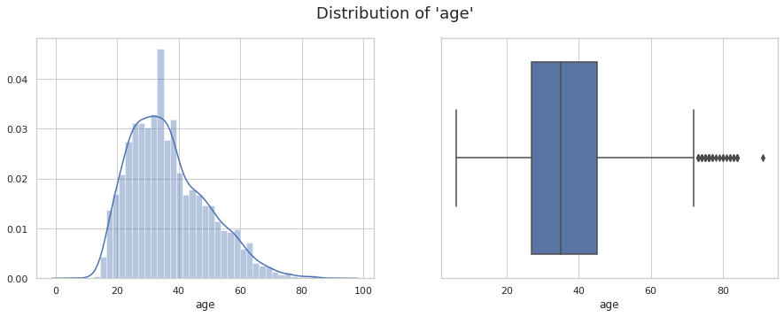

```python
eda_numerical_feat(df['age'], "Distribution of 'age'")
```

## Gender

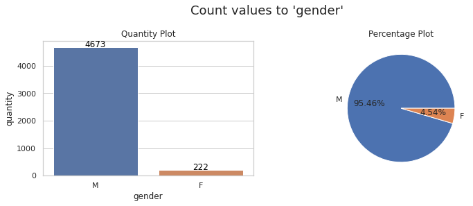

```python
eda_categ_feat_desc_plot(df['gender'], "Count values to 'gender'")
```

## Race

[figure not shown]

```python
eda_categ_feat_desc_plot(df['race'], "Frequency per race")
```

### City and State

```python
eda_categ_feat_desc_df(df['city'])
```

|  | city | quantity | percentage |
| --- | --- | --- | --- |
| 0 | Los Angeles | 78 | 0.0159 |
| 1 | Phoenix | 66 | 0.0135 |
| 2 | Houston | 51 | 0.0104 |
| 3 | Las Vegas | 41 | 0.0084 |
| 4 | San Antonio | 40 | 0.0082 |
| ... | ... | ... | ... |
| 2283 | Big Springs | 1 | 0.0002 |
| 2284 | El Mirage | 1 | 0.0002 |
| 2285 | Norwalk | 1 | 0.0002 |
| 2286 | Glen Burnie | 1 | 0.0002 |
| 2287 | Wayne County | 1 | 0.0002 |

2288 rows × 3 columns

```python
eda_categ_feat_desc_df(df['state']).head()
```

|  | state | quantity | percentage |
| --- | --- | --- | --- |
| 0 | CA | 701 | 0.1432 |
| 1 | TX | 426 | 0.0870 |
| 2 | FL | 324 | 0.0662 |
| 3 | AZ | 222 | 0.0454 |
| 4 | CO | 168 | 0.0343 |

### signs_of_mental_illness

77% False (sem doença mental) e 22% True (doente mental)

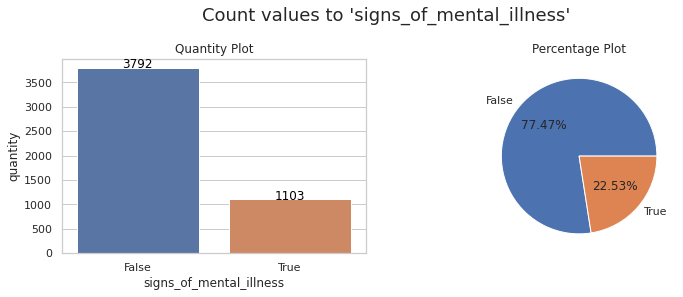

```python
eda_categ_feat_desc_plot(df['signs_of_mental_illness'], "Count values to 'signs_of_mental_illness'")
```

### threat_level

64% "attack", 31% "other", 4% "underteminde"

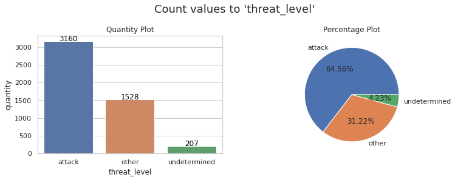

```python
eda_categ_feat_desc_plot(df['threat_level'], "Count values to 'threat_level'")
```

```python
# 'flee', 'body_camera', 'arms_category']
```

### flee

Not flee (62%), 16% car, correndo (13%), 7% othres

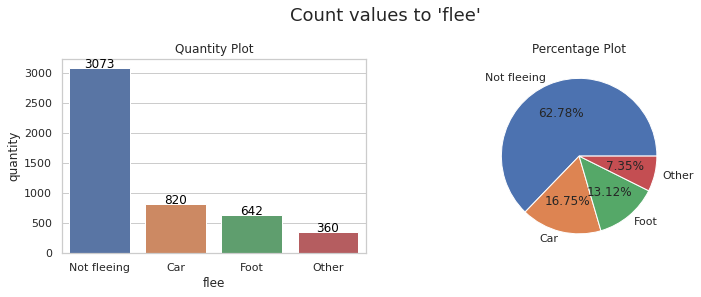

```python
eda_categ_feat_desc_plot(df['flee'], "Count values to 'flee'")
```

### body_camera

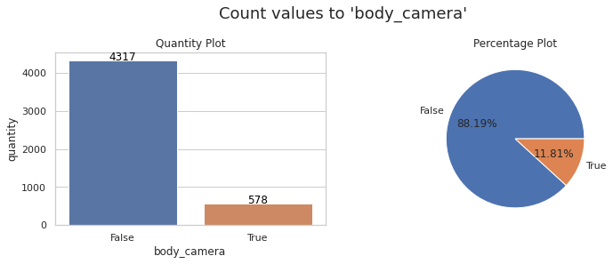

```python
eda_categ_feat_desc_plot(df['body_camera'], "Count values to 'body_camera'")
```

### arms_category

```python
eda_categ_feat_desc_df(df['arms_category'])
```

|  | arms_category | quantity | percentage |
| --- | --- | --- | --- |
| 0 | Guns | 2764 | 0.5647 |
| 1 | Sharp objects | 818 | 0.1671 |
| 2 | Unknown | 418 | 0.0854 |
| 3 | Unarmed | 348 | 0.0711 |
| 4 | Other unusual objects | 192 | 0.0392 |
| 5 | Blunt instruments | 122 | 0.0249 |
| 6 | Vehicles | 121 | 0.0247 |
| 7 | Multiple | 54 | 0.0110 |
| 8 | Piercing objects | 29 | 0.0059 |
| 9 | Electrical devices | 24 | 0.0049 |
| 10 | Explosives | 4 | 0.0008 |
| 11 | Hand tools | 1 | 0.0002 |

## GeoPandas import GeoJson on USA staes

```python
import geopandas as gpd

us_geojson_re = gpd.read_file('../input/us-state-better-view/us-all.geo.json')

# delete uselles columns
list_to_delete = ['id', 'hc-group', 'hc-middle-x', 'hc-middle-y', 'hc-key', 'hc-a2',
       'labelrank', 'hasc', 'woe-id', 'state-fips', 'fips', 'country' , 'longitude',
       'woe-name', 'latitude', 'woe-label', 'type' ]
us_geojson_re = us_geojson_re.drop(list_to_delete, axis = 1)

# remove useless trace to separate alska and havai
us_geojson_re = us_geojson_re.dropna()

us_geojson_re.head()
```

|  | postal-code | name | region | geometry |
| --- | --- | --- | --- | --- |
| 0 | MA | Massachusetts | Northeast | MULTIPOLYGON (((9430.000 7889.000, 9476.000 78... |
| 1 | WA | Washington | West | MULTIPOLYGON (((-77.000 9797.000, -56.000 9768... |
| 2 | CA | California | West | POLYGON ((-833.000 8186.000, -50.000 7955.000,... |
| 3 | OR | Oregon | West | POLYGON ((-50.000 7955.000, -833.000 8186.000,... |
| 4 | WI | Wisconsin | Midwest | MULTIPOLYGON (((6206.000 8297.000, 6197.000 82... |

```python
# Function to generetae GeoJSONSource to generate plots

def generate_GeoJSONSource_to_states(my_df):
    global us_geojson
    geo_source = us_geojson_re.merge(my_df, left_on = 'postal-code', right_on = 'state')
    return GeoJSONDataSource( geojson = geo_source.to_json())

# def generate_GeoJSONSource_to_states(my_df):
#     global us_geojson
#     geo_source = us_geojson.merge(my_df, left_on = 'abreviation', right_on = 'state').drop('abreviation', axis = 1)
#     return GeoJSONDataSource( geojson = geo_source.to_json())
```

mapping states

```python
mapping_us_states = {
 'Alabama' : 'AL',
 'Alaska' : 'AK',
 'Arizona' : 'AZ',
 'Arkansas' : 'AR',
 'California' : 'CA',
 'Colorado' : 'CO',
 'Connecticut' : 'CT',
 'Delaware' : 'DE',
 'Florida' : 'FL',
 'Georgia' : 'GA',
 'Hawaii' : 'HI',
 'Idaho' : 'ID',
 'Illinois' : 'IL',
 'Indiana' : 'IN',
 'Iowa' : 'IA',
 'Kansas' : 'KS',
 'Kentucky' : 'KY',
 'Louisiana' : 'LA',
 'Maine' : 'ME',
 'Maryland' : 'MD',
 'Massachusetts' : 'MA',
 'Michigan' : 'MI',
 'Minnesota' : 'MN',
 'Mississippi' : 'MS',
 'Missouri' : 'MO',
 'Montana' : 'MT',
 'Nebraska' : 'NE',
 'Nevada' : 'NV',
 'New Hampshire' : 'NH',
 'New Jersey' : 'NJ',
 'New Mexico' : 'NM',
 'New York' : 'NY',
 'North Carolina' : 'NC',
 'North Dakota' : 'ND',
 'Ohio' : 'OH',
 'Oklahoma' : 'OK',
 'Oregon' : 'OR',
 'Pennsylvania' : 'PA',
 'Rhode Island' : 'RI',
 'South Carolina' : 'SC',
 'South Dakota' : 'SD',
 'Tennessee' : 'TN',
 'Texas' : 'TX',
 'Utah' : 'UT',
 'Vermont' : 'VT',
 'Virginia' : 'VA',
 'Washington' : 'WA',
 'West Virginia' : 'WV',
 'Wisconsin' : 'WI',
 'Wyoming' : 'WY',
 'District of Columbia': 'DC'
}

mapping_abrev_to_name = {v: k for k, v in mapping_us_states.items()}
# mapping_abrev_to_name
```

```python
df['state_name'] = df['state'].map(lambda state: mapping_abrev_to_name[state])
df.head()
```

[output not shown]

```python
# import geopandas as gpd

# us_geojson = gpd.read_file('../input/us-states-geojson/us-states.json')

# # Dosent exist data of Puerto rico, so delete it
# us_geojson = us_geojson.drop( us_geojson[ us_geojson['name'] == "Puerto Rico" ].index )
# # drop useless columns
# us_geojson = us_geojson.drop(['id', 'density'], axis =1)

# # Map state to dict (convert abreviation to name and otherwise)

# def lambda_state(state):
#     if(state in mapping_us_states.keys()):
#         return mapping_us_states[state]
#     else:
#         return ""

# us_geojson['abreviation'] = us_geojson['name'].map(lambda state: lambda_state(state) )
```

## Total of Ocorrencies per State

```python
primary_column = 'date'
target_column = 'count_ocorrencies'

df1 = df.groupby(['state']).count()[primary_column].reset_index()

eda_geplot_state_rank_plot(df1, primary_column, target_column,
                           "total occurrences by state", "The first and last 8 on ocorrencies count")
```

[interactive chart not shown]

## Analises California

```python
# Top 10 City of CA (California)

df_california = df.query("state == 'CA'").groupby(['city']).count()['date'].sort_values(ascending = False).reset_index().rename({'date': 'count'}, axis = 1)
list_cities_CA = list(df_california.head(10)['city']) # guard 15 biggers count number
df_california.head(10)
```

[output not shown]

```
count   302.0000
mean      2.3212
std       5.1321
min       1.0000
25%       1.0000
50%       1.0000
75%       2.0000
max      78.0000
Name: count, dtype: float64
```

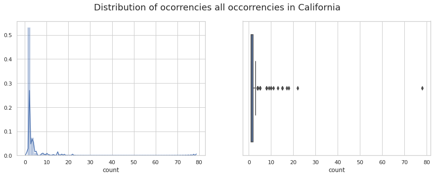

```python
eda_numerical_feat(df_california['count'], "Distribution of ocorrencies all occorrencies in California")
```

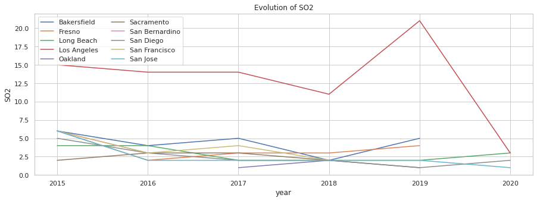

```python
# Plot evolution of bigges 15 city in california

df_california_re = df.query("state == 'CA'")
df_california_re = df.query("city in " + str(list_cities_CA))
df_california_re['year'] = pd.DatetimeIndex(df_california_re['date']).year

fig, ax = plt.subplots(figsize=(15,5))

df_california_re.groupby(['year','city']).count()['id'].unstack().plot(ax=ax)
ax.set_ylabel("SO2")
ax.set_title("S02 Evolution")
ax.set_title("Evolution of SO2")
plt.legend(bbox_to_anchor=(0, 1), loc='upper left', ncol=2)
plt.grid(True)
```

BR

## Analises Biggest cities

```python
df_tops = df.groupby(['city']).count()['date'].sort_values(ascending = False).reset_index().rename({'date': 'count'}, axis = 1)
list_cities_tops = list(df_tops.head(10)['city']) # guard 15 biggers count number
df_tops.head(10)
```

|  | city | count |
| --- | --- | --- |
| 0 | Los Angeles | 78 |
| 1 | Phoenix | 66 |
| 2 | Houston | 51 |
| 3 | Las Vegas | 41 |
| 4 | San Antonio | 40 |
| 5 | Chicago | 38 |
| 6 | Columbus | 36 |
| 7 | Albuquerque | 32 |
| 8 | Jacksonville | 31 |
| 9 | St. Louis | 30 |

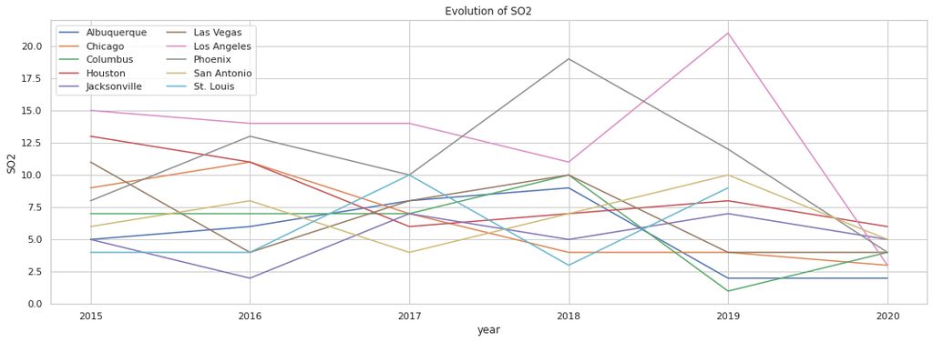

```python
# df_california_re = df.query("state == 'CA'")
df_california_re = df.query("city in " + str(list_cities_tops))
df_california_re['year'] = pd.DatetimeIndex(df_california_re['date']).year

fig, ax = plt.subplots(figsize=(18,6))

df_california_re.groupby(['year','city']).count()['id'].unstack().plot(ax=ax)
ax.set_ylabel("SO2")
ax.set_title("S02 Evolution")
ax.set_title("Evolution of SO2")
plt.legend(bbox_to_anchor=(0, 1), loc='upper left', ncol=2)
plt.grid(True)
```

BR

Depois de Los Angeles, Phoneix tem um grande número de ocorencias. Chicago e Houston já tiveram grandes numero e tem diminuiendo desde que começou a contagem

## Evolution By State

```python
# generate df to plot

df['year'] = pd.DatetimeIndex(df['date']).year
df_re = df.groupby(['year','state_name']).count()['id'].unstack() #unstack is important to make easy make line plot
df_re = df_re.fillna(0) # case dont exist data in this time
df_re
```

| state_name year | Alabama | Alaska | Arizona | Arkansas | California | Colorado | Connecticut | Delaware | District of Columbia | Florida | ... | South Dakota | Tennessee | Texas | Utah | Vermont | Virginia | Washington | West Virginia | Wisconsin | Wyoming |
| --- | --- | --- | --- | --- | --- | --- | --- | --- | --- | --- | --- | --- | --- | --- | --- | --- | --- | --- | --- | --- | --- |
| 2015 | 17.0000 | 4.0000 | 42.0000 | 4.0000 | 182.0000 | 28.0000 | 2.0000 | 3.0000 | 4.0000 | 61.0000 | ... | 3.0000 | 19.0000 | 99.0000 | 10.0000 | 1.0000 | 18.0000 | 16.0000 | 8.0000 | 11.0000 | 5.0000 |
| 2016 | 23.0000 | 6.0000 | 45.0000 | 12.0000 | 127.0000 | 27.0000 | 4.0000 | 1.0000 | 5.0000 | 55.0000 | ... | 4.0000 | 21.0000 | 77.0000 | 8.0000 | 2.0000 | 17.0000 | 24.0000 | 11.0000 | 17.0000 | 2.0000 |
| 2017 | 21.0000 | 7.0000 | 39.0000 | 10.0000 | 143.0000 | 27.0000 | 5.0000 | 5.0000 | 2.0000 | 56.0000 | ... | 3.0000 | 24.0000 | 60.0000 | 7.0000 | 1.0000 | 22.0000 | 30.0000 | 9.0000 | 24.0000 | 1.0000 |
| 2018 | 12.0000 | 7.0000 | 49.0000 | 21.0000 | 96.0000 | 36.0000 | 1.0000 | 0.0000 | 1.0000 | 62.0000 | ... | 1.0000 | 25.0000 | 70.0000 | 18.0000 | 2.0000 | 18.0000 | 16.0000 | 6.0000 | 10.0000 | 4.0000 |
| 2019 | 11.0000 | 6.0000 | 31.0000 | 17.0000 | 111.0000 | 32.0000 | 4.0000 | 0.0000 | 1.0000 | 57.0000 | ... | 3.0000 | 29.0000 | 87.0000 | 11.0000 | 2.0000 | 9.0000 | 30.0000 | 12.0000 | 17.0000 | 1.0000 |
| 2020 | 11.0000 | 6.0000 | 16.0000 | 9.0000 | 42.0000 | 18.0000 | 4.0000 | 1.0000 | 0.0000 | 33.0000 | ... | 0.0000 | 7.0000 | 33.0000 | 4.0000 | 0.0000 | 8.0000 | 10.0000 | 0.0000 | 9.0000 | 0.0000 |

6 rows × 51 columns

```python
# get top and bototm 10 in ranking

int_ranking = 5
df_top_count = df.groupby(['state_name']).count()['id'].reset_index().sort_values(by="id", ascending=False)
top_10_state = list(df_top_count['state_name'][:int_ranking])
bottom_10_state = list(df_top_count['state_name'][-int_ranking:])
print(top_10_state, "\n", bottom_10_state)
```

```
['California', 'Texas', 'Florida', 'Arizona', 'Colorado']
 ['New Hampshire', 'North Dakota', 'Delaware', 'Vermont', 'Rhode Island']
```

```python
from bokeh.palettes import Turbo256
from bokeh.models import Legend

# define pallets of colors
turbo_pallete = Turbo256[0:256:int(256/ (len(top_10_state) + len(bottom_10_state)) )][::-1]

# define x axis
x_axis = np.array([2015,2016,2017,2018,2019,2020])

fig = figure(title="Evolution of the first and last 10 state per total count occorrencies",
             plot_width=800, plot_height=550, x_axis_type="linear")

# is necessary generate a list to put state name in each circle plot with "soruce_re"
def g_list(desc, length):
    l = []
    for i in range(length):
        l.append(desc)
    return l

# Plot Lines
count = 0

for d in top_10_state:
    source_re = ColumnDataSource(dict(x=x_axis, y=np.array(df_re[d]), name=g_list(d, len(x_axis))))
    line = fig.line('x', 'y', legend_label=d, color=turbo_pallete[count] ,line_width=3, source = source_re)
    fig.circle('x', 'y', legend_label=d, color=turbo_pallete[count], fill_color='white', size=7, source = source_re)
    count += 1

for d in bottom_10_state:
    source_re = ColumnDataSource(dict(x=x_axis, y=np.array(df_re[d]), name=g_list(d, len(x_axis))))
    line = fig.line('x', 'y', legend_label=d, color=turbo_pallete[count] ,line_width=3, source = source_re)
    fig.circle('x', 'y', legend_label=d, color=turbo_pallete[count], fill_color='white', size=7, source = source_re)
    count += 1

# plot title
fig.legend.title = 'State'
# Relocate Legend
fig.legend.location = 'bottom_left'
# Click to hide/show lines
fig.legend.click_policy = 'hide'
# Add Hover
fig.add_tools(HoverTool(tooltips=[('State', '@name'),('Year', '@x'),('Count', '@y{%.1f}')], formatters={'@y' : 'printf'} ))

show(fig)
```

[interactive chart not shown]

## Black Case in total

```python
primary_column = 'race'
target_column = 'number_of_occurrences'

df_plot = df.query("race == 'Black'").groupby(['state']).count()[primary_column].reset_index()

eda_geplot_state_rank_plot(df_plot, primary_column, target_column,
                           "total occurrences by state per race Black", "The first and last 8 on ocorrencies count")
```

[interactive chart not shown]

Alguns estados nâo tiveram ocorrencias e aparentemente, os estado que mais estiveram foram os que tem mais no geral

**ATENÇÂO**

Um dado interressenta é que os negros aprecem sofrer bastante violencia perto de DC e NY, ou seja, no nordeste, algo que nao acontece tanto com qualquer outra raça

```python
primary_column = 'date'
target_column = 'count_ocorrencies'

df1 = df.groupby(['state']).count()[primary_column].reset_index()

eda_geplot_state_rank_plot(df1, primary_column, target_column,
                           "total occurrences by state", "The first and last 8 on ocorrencies count")
```

[output not shown]

## Hispanic per state

```python
primary_column = 'race'
target_column = 'number_of_occurrences'

df_plot = df.query("race == 'Hispanic'").groupby(['state']).count()[primary_column].reset_index()

eda_geplot_state_rank_plot(df_plot, primary_column, target_column,
                           "total occurrences by state per race Hispanic", "The first and last 8 on ocorrencies count: Hispanic")
```

[interactive chart not shown]

hispanicos tem mais casos no sudoeste e nao tem naos lugares dos negros. enquanto que os negros mais na costa leste e nao tem no caos dos hispanicos

## Whrite

```python
df['race'].value_counts()
```

```
White       2476
Black       1298
Hispanic     902
Asian         93
Native        78
Other         48
Name: race, dtype: int64
```

```python
primary_column = 'race'
target_column = 'number_of_occurrences'

df_plot = df.query("race == 'White'").groupby(['state']).count()[primary_column].reset_index()

eda_geplot_state_rank_plot(df_plot, primary_column, target_column,
                           "total occurrences by state per race White", "The first and last 8 on ocorrencies count: White")
```

[interactive chart not shown]

## Mais mortes por taser

```python
df.head()
```

|  | id | name | date | manner_of_death | armed | age | gender | race | city | state | signs_of_mental_illness | threat_level | flee | body_camera | arms_category | year | state_name |
| --- | --- | --- | --- | --- | --- | --- | --- | --- | --- | --- | --- | --- | --- | --- | --- | --- | --- |
| 0 | 3 | Tim Elliot | 2015-01-02 | shot | gun | 53.0000 | M | Asian | Shelton | WA | True | attack | Not fleeing | False | Guns | 2015 | Washington |
| 1 | 4 | Lewis Lee Lembke | 2015-01-02 | shot | gun | 47.0000 | M | White | Aloha | OR | False | attack | Not fleeing | False | Guns | 2015 | Oregon |
| 2 | 5 | John Paul Quintero | 2015-01-03 | shot and Tasered | unarmed | 23.0000 | M | Hispanic | Wichita | KS | False | other | Not fleeing | False | Unarmed | 2015 | Kansas |
| 3 | 8 | Matthew Hoffman | 2015-01-04 | shot | toy weapon | 32.0000 | M | White | San Francisco | CA | True | attack | Not fleeing | False | Other unusual objects | 2015 | California |
| 4 | 9 | Michael Rodriguez | 2015-01-04 | shot | nail gun | 39.0000 | M | Hispanic | Evans | CO | False | attack | Not fleeing | False | Piercing objects | 2015 | Colorado |

```python
primary_column = 'race'
target_column = 'number_of_occurrences'

df_plot = df.query("manner_of_death == 'shot and Tasered'").groupby(['state']).count()[primary_column].reset_index()

eda_geplot_state_rank_plot(df_plot, primary_column, target_column,
                           "total occurrences by state in tasered casses", "The first and last 8 on ocorrencies count: tasered casses")
```

[interactive chart not shown]

## DOenaçs mentais

```python
df.head()
```

|  | id | name | date | manner_of_death | armed | age | gender | race | city | state | signs_of_mental_illness | threat_level | flee | body_camera | arms_category | year | state_name |
| --- | --- | --- | --- | --- | --- | --- | --- | --- | --- | --- | --- | --- | --- | --- | --- | --- | --- |
| 0 | 3 | Tim Elliot | 2015-01-02 | shot | gun | 53.0000 | M | Asian | Shelton | WA | True | attack | Not fleeing | False | Guns | 2015 | Washington |
| 1 | 4 | Lewis Lee Lembke | 2015-01-02 | shot | gun | 47.0000 | M | White | Aloha | OR | False | attack | Not fleeing | False | Guns | 2015 | Oregon |
| 2 | 5 | John Paul Quintero | 2015-01-03 | shot and Tasered | unarmed | 23.0000 | M | Hispanic | Wichita | KS | False | other | Not fleeing | False | Unarmed | 2015 | Kansas |
| 3 | 8 | Matthew Hoffman | 2015-01-04 | shot | toy weapon | 32.0000 | M | White | San Francisco | CA | True | attack | Not fleeing | False | Other unusual objects | 2015 | California |
| 4 | 9 | Michael Rodriguez | 2015-01-04 | shot | nail gun | 39.0000 | M | Hispanic | Evans | CO | False | attack | Not fleeing | False | Piercing objects | 2015 | Colorado |

```python
primary_column = 'race'
target_column = 'number_of_occurrences'

df_plot = df.query("race == 'Asian'").groupby(['state']).count()[primary_column].reset_index()

eda_geplot_state_rank_plot(df_plot, primary_column, target_column,
                           "total occurrences by state in tasered casses", "The first and last 8 on ocorrencies count: tasered casses")
```

[interactive chart not shown]

Para asiaticos o curioso doi Whashignto e Havai, caracterisando assim paises mais ao leste, talvez por estar mais perto da asia

## Armas category = guns

arms_category

```python
df.head()
```

|  | id | name | date | manner_of_death | armed | age | gender | race | city | state | signs_of_mental_illness | threat_level | flee | body_camera | arms_category | year | state_name |
| --- | --- | --- | --- | --- | --- | --- | --- | --- | --- | --- | --- | --- | --- | --- | --- | --- | --- |
| 0 | 3 | Tim Elliot | 2015-01-02 | shot | gun | 53.0000 | M | Asian | Shelton | WA | True | attack | Not fleeing | False | Guns | 2015 | Washington |
| 1 | 4 | Lewis Lee Lembke | 2015-01-02 | shot | gun | 47.0000 | M | White | Aloha | OR | False | attack | Not fleeing | False | Guns | 2015 | Oregon |
| 2 | 5 | John Paul Quintero | 2015-01-03 | shot and Tasered | unarmed | 23.0000 | M | Hispanic | Wichita | KS | False | other | Not fleeing | False | Unarmed | 2015 | Kansas |
| 3 | 8 | Matthew Hoffman | 2015-01-04 | shot | toy weapon | 32.0000 | M | White | San Francisco | CA | True | attack | Not fleeing | False | Other unusual objects | 2015 | California |
| 4 | 9 | Michael Rodriguez | 2015-01-04 | shot | nail gun | 39.0000 | M | Hispanic | Evans | CO | False | attack | Not fleeing | False | Piercing objects | 2015 | Colorado |

```python
primary_column = 'race'
target_column = 'number_of_occurrences'

df_plot = df.query("armed == 'gun'").groupby(['state']).count()[primary_column].reset_index()

# df_plot
eda_geplot_state_rank_plot(df_plot, primary_column, target_column,
                           "total occurrences by state in tasered casses", "The first and last 8 on ocorrencies count: tasered casses")
```

[interactive chart not shown]

signs_of_mental_illness

```python
df.head()
```

|  | id | name | date | manner_of_death | armed | age | gender | race | city | state | signs_of_mental_illness | threat_level | flee | body_camera | arms_category | year | state_name |
| --- | --- | --- | --- | --- | --- | --- | --- | --- | --- | --- | --- | --- | --- | --- | --- | --- | --- |
| 0 | 3 | Tim Elliot | 2015-01-02 | shot | gun | 53.0000 | M | Asian | Shelton | WA | True | attack | Not fleeing | False | Guns | 2015 | Washington |
| 1 | 4 | Lewis Lee Lembke | 2015-01-02 | shot | gun | 47.0000 | M | White | Aloha | OR | False | attack | Not fleeing | False | Guns | 2015 | Oregon |
| 2 | 5 | John Paul Quintero | 2015-01-03 | shot and Tasered | unarmed | 23.0000 | M | Hispanic | Wichita | KS | False | other | Not fleeing | False | Unarmed | 2015 | Kansas |
| 3 | 8 | Matthew Hoffman | 2015-01-04 | shot | toy weapon | 32.0000 | M | White | San Francisco | CA | True | attack | Not fleeing | False | Other unusual objects | 2015 | California |
| 4 | 9 | Michael Rodriguez | 2015-01-04 | shot | nail gun | 39.0000 | M | Hispanic | Evans | CO | False | attack | Not fleeing | False | Piercing objects | 2015 | Colorado |

```python
primary_column = 'race'
target_column = 'number_of_occurrences'

df_plot = df.query("signs_of_mental_illness == True").groupby(['state']).count()[primary_column].reset_index()

# df_plot
eda_geplot_state_rank_plot(df_plot, primary_column, target_column,
                           "total occurrences by state in tasered casses", "The first and last 8 on ocorrencies count: tasered casses")
```

[interactive chart not shown]

## Comparar com censo demografico

```python
# pd.reset_option("display.float_format")
```

```python
df_census1 = pd.read_csv("../input/us-census-demographic-data/acs2017_county_data.csv")
df_census1.head(1)
```

|  | CountyId | State | County | TotalPop | Men | Women | Hispanic | White | Black | Native | ... | Walk | OtherTransp | WorkAtHome | MeanCommute | Employed | PrivateWork | PublicWork | SelfEmployed | FamilyWork | Unemployment |
| --- | --- | --- | --- | --- | --- | --- | --- | --- | --- | --- | --- | --- | --- | --- | --- | --- | --- | --- | --- | --- | --- |
| 0 | 1001 | Alabama | Autauga County | 55036 | 26899 | 28137 | 2.7 | 75.4 | 18.9 | 0.3 | ... | 0.6 | 1.3 | 2.5 | 25.8 | 24112 | 74.1 | 20.2 | 5.6 | 0.1 | 5.2 |

1 rows × 37 columns

```python
print(list(df_census1.columns))
```

[output not shown]

```python
df_census = pd.read_csv("../input/us-census-demographic-data/acs2017_county_data.csv")
list_indexs = df_census[ df_census['State'] == 'Puerto Rico'].index
df_census = df_census.drop(list_indexs)
df_census['state'] = df_census['State'].map(lambda x: mapping_us_states[x])
df_census.head(1)
```

|  | CountyId | State | County | TotalPop | Men | Women | Hispanic | White | Black | Native | ... | OtherTransp | WorkAtHome | MeanCommute | Employed | PrivateWork | PublicWork | SelfEmployed | FamilyWork | Unemployment | state |
| --- | --- | --- | --- | --- | --- | --- | --- | --- | --- | --- | --- | --- | --- | --- | --- | --- | --- | --- | --- | --- | --- |
| 0 | 1001 | Alabama | Autauga County | 55036 | 26899 | 28137 | 2.7 | 75.4 | 18.9 | 0.3 | ... | 1.3 | 2.5 | 25.8 | 24112 | 74.1 | 20.2 | 5.6 | 0.1 | 5.2 | AL |

1 rows × 38 columns

```python
df_census["BlackPopulation"] = ((df_census["TotalPop"]/100) * df_census["Black"]).astype('int')
df_census["HispanicPopulation"] = ((df_census["TotalPop"]/100) * df_census["Hispanic"]).astype('int')
df_census["WhitePopulation"] = ((df_census["TotalPop"]/100) * df_census["White"]).astype('int')
```

```python
primary_column = 'TotalPop'
target_column = 'population'

total_pop = df_census.groupby(['state']).sum()['TotalPop'].reset_index().sort_values(by="TotalPop", ascending=False)

eda_geplot_state_rank_plot(total_pop, primary_column, target_column,
                           "Population by 2017 census", "The first and last 8 on ocorrencies count: tasered casses")
```

[interactive chart not shown]

```python
primary_column = 'BlackPopulation'
target_column = 'population'

df3 = df_census.groupby(['state']).sum()[primary_column].reset_index().sort_values(by=primary_column, ascending=False)

eda_geplot_state_rank_plot(df3, primary_column, target_column,
                           "Population by 2017: Black Pop census", "The first and last 8 on ocorrencies count: tasered casses")
```

[interactive chart not shown]

```python
primary_column = 'HispanicPopulation'
target_column = 'population'

df3 = df_census.groupby(['state']).sum()[primary_column].reset_index().sort_values(by=primary_column, ascending=False)

eda_geplot_state_rank_plot(df3, primary_column, target_column,
                           "Population by 2017: Black Pop census", "The first and last 8 on ocorrencies count: tasered casses")
```

[interactive chart not shown]

Percentagem

```python
df3 = df_census.groupby(['state']).sum()['TotalPop'].reset_index().sort_values(by="TotalPop", ascending=False)
```

```python
primary_column = 'HispanicPopulation'
target_column = 'population'

# brazil_geojson.merge(df_price, left_on = 'state_sigla', right_on = 'state').drop(['state_sigla'], axis = 1)

df3 = df_census.groupby(['state']).sum()[primary_column].reset_index().sort_values(by=primary_column, ascending=False)
df4 = df3.merge(total_pop, left_on = 'state', right_on = 'state')
df4['percentage_hispanic'] = df4['HispanicPopulation'] / df4['TotalPop']
df4 = df4.sort_values(by='percentage_hispanic', ascending=False)

primary_column = 'percentage_hispanic'
# df4
eda_geplot_state_rank_plot(df4, primary_column, target_column,
                           "Population by 2017: Hispanic % census", "The first and last 8 on ocorrencies count: tasered casses")
```

[interactive chart not shown]

```python
primary_column = 'BlackPopulation'
target_column = 'population'

# brazil_geojson.merge(df_price, left_on = 'state_sigla', right_on = 'state').drop(['state_sigla'], axis = 1)

df3 = df_census.groupby(['state']).sum()[primary_column].reset_index().sort_values(by=primary_column, ascending=False)
df4 = df3.merge(total_pop, left_on = 'state', right_on = 'state')
df4['percentage_black'] = df4['BlackPopulation'] / df4['TotalPop']
df4 = df4.sort_values(by='percentage_black', ascending=False)

primary_column = 'percentage_black'
# df4
eda_geplot_state_rank_plot(df4, primary_column, target_column,
                           "Population by 2017: Black % census", "The first and last 8 on ocorrencies count: tasered casses")
```

[interactive chart not shown]

```python
primary_column = 'WhitePopulation'
target_column = 'population'

# brazil_geojson.merge(df_price, left_on = 'state_sigla', right_on = 'state').drop(['state_sigla'], axis = 1)

df3 = df_census.groupby(['state']).sum()[primary_column].reset_index().sort_values(by=primary_column, ascending=False)
df4 = df3.merge(total_pop, left_on = 'state', right_on = 'state')
df4['percentage_White'] = df4['WhitePopulation'] / df4['TotalPop']
df4 = df4.sort_values(by='percentage_White', ascending=False)

primary_column = 'percentage_White'
# df4
eda_geplot_state_rank_plot(df4, primary_column, target_column,
                           "Population by 2017: White % census", "The first and last 8 on ocorrencies count: tasered casses")
```

[interactive chart not shown]

Demograficamente podems observar que

O sul é divido em a leste hispanicos e a oeste negros e umpouco ao norte do oetse incluindo NY

Os brancos, todo o norte